# Predictive Power Comparison

Jingjing

## County Level Analysis

### Prediction Preparation

Here we use code liberally borrowed from a [blog post](https://github.com/cmu-delphi/delphi-blog/blob/main/content/post/2020-09-21-forecast-demo.Rmd) to perform a prediction task.

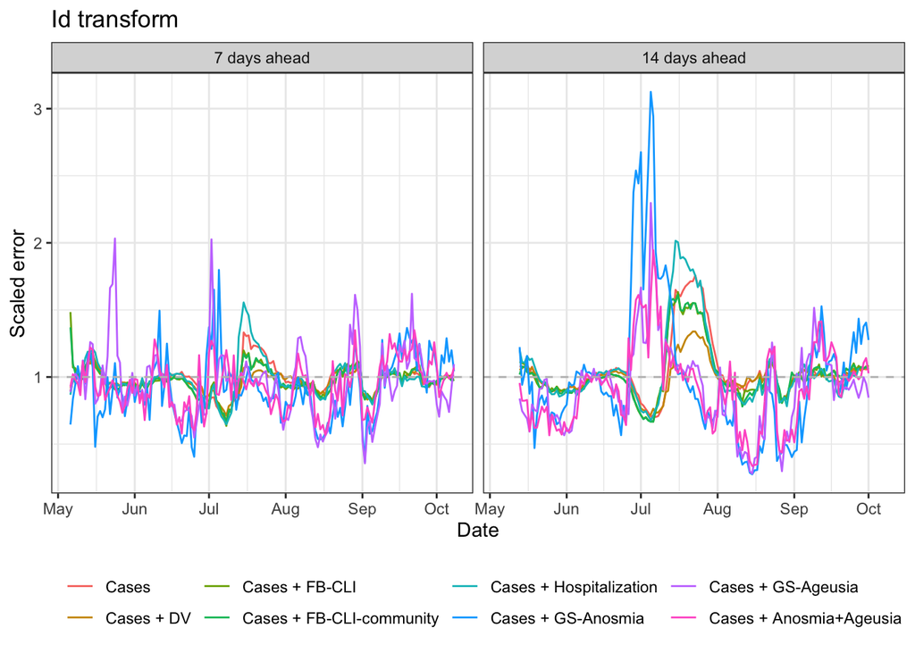

We can see that during some time periods, median scaled error for the cases + google-symptoms (anosmia, ageusia, A+A) model is more variable than other signals at county level.

Test period: 2020-05-06 to 2020-09-27 , common time period

| Model | Target | Median scaled error | Test days |
| --- | --- | --- | --- |
| Cases | 7 days ahead | 1.006 | 145 |
| Cases + DV | 7 days ahead | 0.978 | 145 |
| Cases + FB-CLI | 7 days ahead | 0.951 | 145 |
| Cases + FB-CLI-community | 7 days ahead | 0.949 | 145 |
| Cases + Hospitalization | 7 days ahead | 0.986 | 145 |
| Cases + GS-Anosmia | 7 days ahead | 0.887 | 145 |
| Cases + GS-Ageusia | 7 days ahead | 0.931 | 145 |
| Cases + Anosmia+Ageusia | 7 days ahead | 0.899 | 145 |
| Cases | 14 days ahead | 1.081 | 138 |
| Cases + DV | 14 days ahead | 1.013 | 138 |
| Cases + FB-CLI | 14 days ahead | 1.013 | 138 |
| Cases + FB-CLI-community | 14 days ahead | 1.024 | 138 |
| Cases + Hospitalization | 14 days ahead | 1.075 | 138 |
| Cases + GS-Anosmia | 14 days ahead | 0.931 | 138 |
| Cases + GS-Ageusia | 14 days ahead | 0.935 | 138 |
| Cases + Anosmia+Ageusia | 14 days ahead | 0.869 | 138 |

Calculating median scaled error over all dates and all counties for a given model, we see that adding symptoms as a predictor reduces median scaled error by approximately 10 percentage points (and approximately 10%) compared to a cases-only model.

“Are these differences in median scaled errors significant? It’s hard to say [for certain, given the spatial and temporal dependence of the data], but some basic hypothesis testing suggests that they probably are: below we conduct a sign test for whether the difference in the “Cases” model’s scaled error and each other model’s scaled error is centered at zero" ([source](https://delphi.cmu.edu/blog/2020/09/21/can-symptoms-surveys-improve-covid-19-forecasts/)).

| Comparison | Target | P-value |
| --- | --- | --- |
| Cases vs Cases + DV | 7 days ahead | 0.0000000 |
| Cases vs Cases + DV | 14 days ahead | 0.0000000 |
| Cases vs Cases + FB-CLI | 7 days ahead | 0.0000000 |
| Cases vs Cases + FB-CLI | 14 days ahead | 0.0000000 |
| Cases vs Cases + FB-CLI-community | 7 days ahead | 0.0000000 |
| Cases vs Cases + FB-CLI-community | 14 days ahead | 0.0000000 |
| Cases vs Cases + Hospitalization | 7 days ahead | 0.0000000 |
| Cases vs Cases + Hospitalization | 14 days ahead | 0.3236017 |
| Cases vs Cases + GS-Anosmia | 7 days ahead | 0.0000000 |
| Cases vs Cases + GS-Anosmia | 14 days ahead | 0.0000000 |
| Cases vs Cases + GS-Ageusia | 7 days ahead | 0.0000000 |
| Cases vs Cases + GS-Ageusia | 14 days ahead | 0.0000000 |
| Cases vs Cases + Anosmia+Ageusia | 7 days ahead | 0.0000000 |
| Cases vs Cases + Anosmia+Ageusia | 14 days ahead | 0.0000000 |

“To mitigate the dependence across time (which intuitively seems to matter more than that across space), we recomputed these tests in a stratified way, where for each day we run a sign test on the scaled errors between two models over all [geographic regions]. The results are plotted as histograms below”, where one count corresponds to one prediction date ([source](https://delphi.cmu.edu/blog/2020/09/21/can-symptoms-surveys-improve-covid-19-forecasts/)).

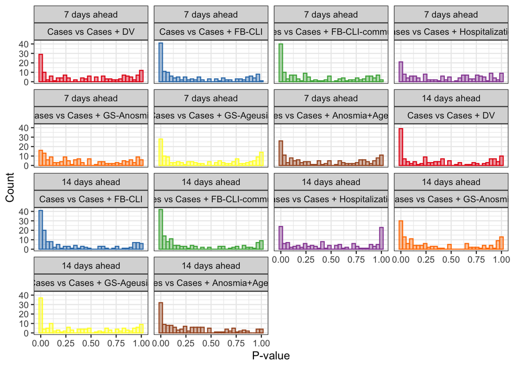

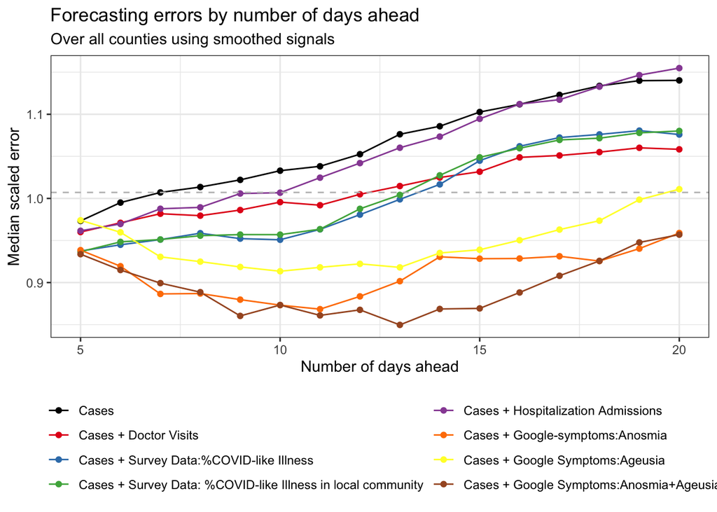

We can see that models containing GS outperform other models including Case-only and Cases + other signals. Errors are calculated on a shared-time basis. With all models together, more dates are dropped and it causes shifts in some error values. In fact, it shows that the prediction of cases + GS model is of high quality though with low geographical coverage.